[Edit on GitHub](https://github.com/JuliaManifolds/Manifolds.jl/blob/master/docs/src/manifolds/sphere.md)

# Sphere and unit norm arrays

`Manifolds.AbstractSphere` — Type

```julia
AbstractSphere{𝔽} <: AbstractEmbeddedManifold{𝔽,DefaultIsometricEmbeddingType}
```

An abstract type to represent a unit sphere that is represented isometrically in the embedding.

[source](https://github.com/JuliaManifolds/Manifolds.jl/blob/d11e5d534f0f3d617a4e781b4b19328c07584cf3/src/manifolds/Sphere.jl#L1-L5)

The classical sphere, i.e. unit norm (real- or complex-valued) vectors can be generated as usual: to create the 2-dimensional sphere (in $ℝ^3$), use `Sphere(2)` and `Sphere(2,ℂ)`, respectively.

`Manifolds.Sphere` — Type

```julia
Sphere{n,𝔽} <: AbstractSphere{𝔽}
```

The (unit) sphere manifold $𝕊^{n}$ is the set of all unit norm vectors in $𝔽^{n+1}$. The sphere is represented in the embedding, i.e.

\[𝕊^{n} := \bigl\{ p \in 𝔽^{n+1}\ \big|\ \lVert p \rVert = 1 \bigr\}\]

where $𝔽\in\{ℝ,ℂ,ℍ\}$. Note that compared to the `ArraySphere`, here the argument `n` of the manifold is the dimension of the manifold, i.e. $𝕊^{n} ⊂ 𝔽^{n+1}$, $n\in ℕ$.

The tangent space at point $p$ is given by

\[T_p𝕊^{n} := \bigl\{ X ∈ 𝔽^{n+1}\ |\ \Re(⟨p,X⟩) = 0 \bigr \},\]

where $𝔽\in\{ℝ,ℂ,ℍ\}$ and $⟨\cdot,\cdot⟩$ denotes the inner product in the embedding $𝔽^{n+1}$.

For $𝔽=ℂ$, the manifold is the complex sphere, written $ℂ𝕊^n$, embedded in $ℂ^{n+1}$. $ℂ𝕊^n$ is the complexification of the real sphere $𝕊^{2n+1}$. Likewise, the quaternionic sphere $ℍ𝕊^n$ is the quaternionification of the real sphere $𝕊^{4n+3}$. Consequently, $ℂ𝕊^0$ is equivalent to $𝕊^1$ and `Circle`, while $ℂ𝕊^1$ and $ℍ𝕊^0$ are equivalent to $𝕊^3$, though with different default representations.

This manifold is modeled as a special case of the more general case, i.e. as an embedded manifold to the `Euclidean`, and several functions like the `inner` product and the `zero_vector` are inherited from the embedding.

**Constructor**

```
Sphere(n[, field=ℝ])
```

Generate the (real-valued) sphere $𝕊^{n} ⊂ ℝ^{n+1}$, where `field` can also be used to generate the complex- and quaternionic-valued sphere.

[source](https://github.com/JuliaManifolds/Manifolds.jl/blob/d11e5d534f0f3d617a4e781b4b19328c07584cf3/src/manifolds/Sphere.jl#L8-L47)

For the higher-dimensional arrays, for example unit (Frobenius) norm matrices, the manifold is generated using the size of the matrix. To create the unit sphere of $3×2$ real-valued matrices, write `ArraySphere(3,2)` and the complex case is done – as for the `Euclidean` case – with an keyword argument `ArraySphere(3,2; field = ℂ)`. This case also covers the classical sphere as a special case, but you specify the size of the vectors/embedding instead: The 2-sphere can here be generated `ArraySphere(3)`.

`Manifolds.ArraySphere` — Type

```julia
ArraySphere{T<:Tuple,𝔽} <: AbstractSphere{𝔽}
```

The (unit) sphere manifold $𝕊^{n₁,n₂,...,nᵢ}$ is the set of all unit (Frobenius) norm elements of $𝔽^{n₁,n₂,...,nᵢ}$, where 𝔽\in{ℝ,ℂ,ℍ}. The generalized sphere is represented in the embedding, and supports arbitrary sized arrays or in other words arbitrary tensors of unit norm. The set formally reads

\[𝕊^{n_1, n_2, …, n_i} := \bigl\{ p \in 𝔽^{n_1, n_2, …, n_i}\ \big|\ \lVert p \rVert = 1 \bigr\}\]

where $𝔽\in\{ℝ,ℂ,ℍ\}$. Setting $i=1$ and $𝔽=ℝ$ this simplifies to unit vectors in $ℝ^n$, see `Sphere` for this special case. Note that compared to this classical case, the argument for the generalized case here is given by the dimension of the embedding. This means that `Sphere(2)` and `ArraySphere(3)` are the same manifold.

The tangent space at point $p$ is given by

\[T_p 𝕊^{n_1, n_2, …, n_i} := \bigl\{ X ∈ 𝔽^{n_1, n_2, …, n_i}\ |\ \Re(⟨p,X⟩) = 0 \bigr \},\]

where $𝔽\in\{ℝ,ℂ,ℍ\}$ and $⟨\cdot,\cdot⟩$ denotes the (Frobenius) inner product in the embedding $𝔽^{n_1, n_2, …, n_i}$.

This manifold is modeled as an embedded manifold to the `Euclidean`, i.e. several functions like the `inner` product and the `zero_vector` are inherited from the embedding.

**Constructor**

```
ArraySphere(n₁,n₂,...,nᵢ; field=ℝ)
```

Generate sphere in $𝔽^{n_1, n_2, …, n_i}$, where $𝔽$ defaults to the real-valued case $ℝ$.

[source](https://github.com/JuliaManifolds/Manifolds.jl/blob/d11e5d534f0f3d617a4e781b4b19328c07584cf3/src/manifolds/Sphere.jl#L51-L86)

There is also one atlas available on the sphere.

`Manifolds.StereographicAtlas` — Type

```julia
StereographicAtlas()
```

The stereographic atlas of $S^n$ with two charts: one with the singular point (-1, 0, ..., 0) (called `:north`) and one with the singular point (1, 0, ..., 0) (called `:south`).

[source](https://github.com/JuliaManifolds/Manifolds.jl/blob/d11e5d534f0f3d617a4e781b4b19328c07584cf3/src/manifolds/Sphere.jl#L468-L474)

## Functions on unit spheres

`Base.exp` — Method

```julia
exp(M::AbstractSphere, p, X)
```

Compute the exponential map from `p` in the tangent direction `X` on the `AbstractSphere` `M` by following the great arc eminating from `p` in direction `X`.

\[\exp_p X = \cos(\lVert X \rVert_p)p + \sin(\lVert X \rVert_p)\frac{X}{\lVert X \rVert_p},\]

where $\lVert X \rVert_p$ is the `norm` on the tangent space at `p` of the `AbstractSphere` `M`.

[source](https://github.com/JuliaManifolds/Manifolds.jl/blob/d11e5d534f0f3d617a4e781b4b19328c07584cf3/src/manifolds/Sphere.jl#L162-L173)

`Base.log` — Method

```julia
log(M::AbstractSphere, p, q)
```

Compute the logarithmic map on the `AbstractSphere` `M`, i.e. the tangent vector, whose geodesic starting from `p` reaches `q` after time 1. The formula reads for $x ≠ -y$

\[\log_p q = d_{𝕊}(p,q) \frac{q-\Re(⟨p,q⟩) p}{\lVert q-\Re(⟨p,q⟩) p \rVert_2},\]

and a deterministic choice from the set of tangent vectors is returned if $x=-y$, i.e. for opposite points.

[source](https://github.com/JuliaManifolds/Manifolds.jl/blob/d11e5d534f0f3d617a4e781b4b19328c07584cf3/src/manifolds/Sphere.jl#L306-L319)

`Manifolds.uniform_distribution` — Method

```julia
uniform_distribution(M::Sphere{n,ℝ}, p) where {n}
```

Uniform distribution on given `Sphere` `M`. Generated points will be of similar type as `p`.

[source](https://github.com/JuliaManifolds/Manifolds.jl/blob/d11e5d534f0f3d617a4e781b4b19328c07584cf3/src/manifolds/Sphere.jl#L436-L441)

`ManifoldsBase.check_point` — Method

```julia
check_point(M::AbstractSphere, p; kwargs...)
```

Check whether `p` is a valid point on the `AbstractSphere` `M`, i.e. is a point in the embedding of unit length. The tolerance for the last test can be set using the `kwargs...`.

[source](https://github.com/JuliaManifolds/Manifolds.jl/blob/d11e5d534f0f3d617a4e781b4b19328c07584cf3/src/manifolds/Sphere.jl#L92-L98)

`ManifoldsBase.check_vector` — Method

```julia
check_vector(M::AbstractSphere, p, X; kwargs... )
```

Check whether `X` is a tangent vector to `p` on the `AbstractSphere` `M`, i.e. after `check_point``(M,p)`, `X` has to be of same dimension as `p` and orthogonal to `p`. The tolerance for the last test can be set using the `kwargs...`.

[source](https://github.com/JuliaManifolds/Manifolds.jl/blob/d11e5d534f0f3d617a4e781b4b19328c07584cf3/src/manifolds/Sphere.jl#L117-L124)

`ManifoldsBase.distance` — Method

```julia
distance(M::AbstractSphere, p, q)
```

Compute the geodesic distance betweeen `p` and `q` on the `AbstractSphere` `M`. The formula is given by the (shorter) great arc length on the (or a) great circle both `p` and `q` lie on.

\[d_{𝕊}(p,q) = \arccos(\Re(⟨p,q⟩)).\]

[source](https://github.com/JuliaManifolds/Manifolds.jl/blob/d11e5d534f0f3d617a4e781b4b19328c07584cf3/src/manifolds/Sphere.jl#L149-L159)

`ManifoldsBase.get_coordinates` — Method

```julia
get_coordinates(M::AbstractSphere{ℝ}, p, X, B::DefaultOrthonormalBasis)
```

Represent the tangent vector `X` at point `p` from the `AbstractSphere` `M` in an orthonormal basis by rotating the hyperplane containing `X` to a hyperplane whose normal is the $x$-axis.

Given $q = p λ + x$, where $λ = \operatorname{sgn}(⟨x, p⟩)$, and $⟨⋅, ⋅⟩_{\mathrm{F}}$ denotes the Frobenius inner product, the formula for $Y$ is

\[\begin{pmatrix}0 \\ Y\end{pmatrix} = X - q\frac{2 ⟨q, X⟩_{\mathrm{F}}}{⟨q, q⟩_{\mathrm{F}}}.\]

[source](https://github.com/JuliaManifolds/Manifolds.jl/blob/d11e5d534f0f3d617a4e781b4b19328c07584cf3/src/manifolds/Sphere.jl#L197-L209)

`ManifoldsBase.get_vector` — Method

```julia
get_vector(M::AbstractSphere{ℝ}, p, X, B::DefaultOrthonormalBasis)
```

Convert a one-dimensional vector of coefficients `X` in the basis `B` of the tangent space at `p` on the `AbstractSphere` `M` to a tangent vector `Y` at `p` by rotating the hyperplane containing `X`, whose normal is the $x$-axis, to the hyperplane whose normal is `p`.

Given $q = p λ + x$, where $λ = \operatorname{sgn}(⟨x, p⟩)$, and $⟨⋅, ⋅⟩_{\mathrm{F}}$ denotes the Frobenius inner product, the formula for $Y$ is

\[Y = X - q\frac{2 \left\langle q, \begin{pmatrix}0 \\ X\end{pmatrix}\right\rangle_{\mathrm{F}}}{⟨q, q⟩_{\mathrm{F}}}.\]

[source](https://github.com/JuliaManifolds/Manifolds.jl/blob/d11e5d534f0f3d617a4e781b4b19328c07584cf3/src/manifolds/Sphere.jl#L229-L242)

`ManifoldsBase.injectivity_radius` — Method

```julia
injectivity_radius(M::AbstractSphere[, p])
```

Return the injectivity radius for the `AbstractSphere` `M`, which is globally $π$.

```
injectivity_radius(M::Sphere, x, ::ProjectionRetraction)
```

Return the injectivity radius for the `ProjectionRetraction` on the `AbstractSphere`, which is globally $\frac{π}{2}$.

[source](https://github.com/JuliaManifolds/Manifolds.jl/blob/d11e5d534f0f3d617a4e781b4b19328c07584cf3/src/manifolds/Sphere.jl#L264-L273)

`ManifoldsBase.inverse_retract` — Method

```julia
inverse_retract(M::AbstractSphere, p, q, ::ProjectionInverseRetraction)
```

Compute the inverse of the projection based retraction on the `AbstractSphere` `M`, i.e. rearranging $p+X = q\lVert p+X\rVert_2$ yields since $\Re(⟨p,X⟩) = 0$ and when $d_{𝕊^2}(p,q) ≤ \frac{π}{2}$ that

\[\operatorname{retr}_p^{-1}(q) = \frac{q}{\Re(⟨p, q⟩)} - p.\]

[source](https://github.com/JuliaManifolds/Manifolds.jl/blob/d11e5d534f0f3d617a4e781b4b19328c07584cf3/src/manifolds/Sphere.jl#L289-L299)

`ManifoldsBase.manifold_dimension` — Method

```julia
manifold_dimension(M::AbstractSphere)
```

Return the dimension of the `AbstractSphere` `M`, respectively i.e. the dimension of the embedding -1.

[source](https://github.com/JuliaManifolds/Manifolds.jl/blob/d11e5d534f0f3d617a4e781b4b19328c07584cf3/src/manifolds/Sphere.jl#L340-L345)

`ManifoldsBase.project` — Method

```julia
project(M::AbstractSphere, p, X)
```

Project the point `X` onto the tangent space at `p` on the `Sphere` `M`.

\[\operatorname{proj}_{p}(X) = X - \Re(⟨p, X⟩)p\]

[source](https://github.com/JuliaManifolds/Manifolds.jl/blob/d11e5d534f0f3d617a4e781b4b19328c07584cf3/src/manifolds/Sphere.jl#L393-L401)

`ManifoldsBase.project` — Method

```julia
project(M::AbstractSphere, p)
```

Project the point `p` from the embedding onto the `Sphere` `M`.

\[\operatorname{proj}(p) = \frac{p}{\lVert p \rVert},\]

where $\lVert\cdot\rVert$ denotes the usual 2-norm for vectors if $m=1$ and the Frobenius norm for the case $m>1$.

[source](https://github.com/JuliaManifolds/Manifolds.jl/blob/d11e5d534f0f3d617a4e781b4b19328c07584cf3/src/manifolds/Sphere.jl#L378-L388)

`ManifoldsBase.representation_size` — Method

```julia
representation_size(M::AbstractSphere)
```

Return the size points on the `AbstractSphere` `M` are represented as, i.e., the representation size of the embedding.

[source](https://github.com/JuliaManifolds/Manifolds.jl/blob/d11e5d534f0f3d617a4e781b4b19328c07584cf3/src/manifolds/Sphere.jl#L406-L411)

`ManifoldsBase.retract` — Method

```julia
retract(M::AbstractSphere, p, X, ::ProjectionRetraction)
```

Compute the retraction that is based on projection, i.e.

\[\operatorname{retr}_p(X) = \frac{p+X}{\lVert p+X \rVert_2}\]

[source](https://github.com/JuliaManifolds/Manifolds.jl/blob/d11e5d534f0f3d617a4e781b4b19328c07584cf3/src/manifolds/Sphere.jl#L415-L423)

`ManifoldsBase.vector_transport_to` — Method

```julia
vector_transport_to(M::AbstractSphere, p, X, q, ::ParallelTransport)
```

Compute the parallel transport on the `Sphere` of the tangent vector `X` at `p` to `q`, provided, the `geodesic` between `p` and `q` is unique. The formula reads

\[P_{p←q}(X) = X - \frac{\Re(⟨\log_p q,X⟩_p)}{d^2_𝕊(p,q)} \bigl(\log_p q + \log_q p \bigr).\]

[source](https://github.com/JuliaManifolds/Manifolds.jl/blob/d11e5d534f0f3d617a4e781b4b19328c07584cf3/src/manifolds/Sphere.jl#L447-L457)

`Statistics.mean` — Method

```julia
mean(
    S::AbstractSphere,
    x::AbstractVector,
    [w::AbstractWeights,]
    method = GeodesicInterpolationWithinRadius(π/2);
    kwargs...,
)
```

Compute the Riemannian `mean` of `x` using `GeodesicInterpolationWithinRadius`.

[source](https://github.com/JuliaManifolds/Manifolds.jl/blob/d11e5d534f0f3d617a4e781b4b19328c07584cf3/src/manifolds/Sphere.jl#L348-L359)

## Visualization on `Sphere{2,ℝ}`

You can visualize both points and tangent vectors on the sphere.

Note

There seems to be no unified way to draw spheres in the backends of [Plots.jl](http://docs.juliaplots.org/latest/). This recipe currently uses the `seriestype` `wireframe` and `surface`, which does not yet work with the default backend [`GR`](https://github.com/jheinen/GR.jl).

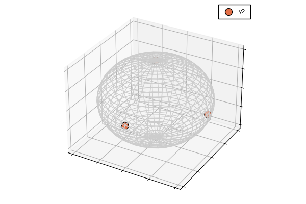

```julia
using Manifolds, Plots
pyplot()
M = Sphere(2)
pts = [ [1.0, 0.0, 0.0], [0.0, -1.0, 0.0], [0.0, 0.0, 1.0], [1.0, 0.0, 0.0] ]
scene = plot(M, pts; wireframe_color=colorant"#CCCCCC", markersize=10)
```

which scatters our points. We can also draw connecting geodesics, which here is a geodesic triangle. Here we discretize each geodesic with 100 points along the geodesic. The default value is `geodesic_interpolation=-1` which switches to scatter plot of the data.

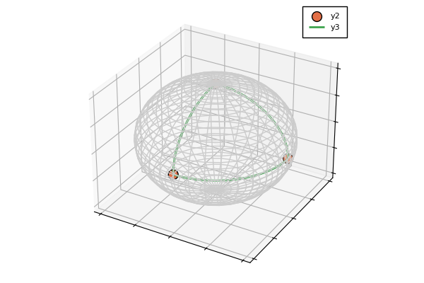

```julia
plot!(scene, M, pts; wireframe=false, geodesic_interpolation=100, linewidth=2)
```

And we can also add tangent vectors, for example tangents pointing towards the geometric center of given points.

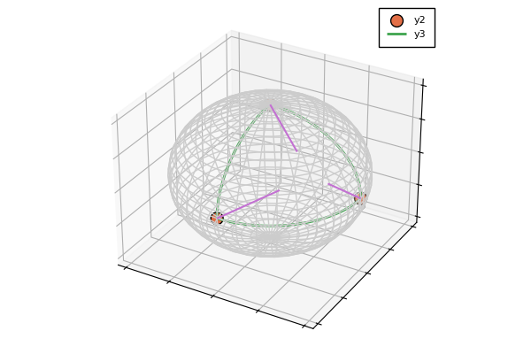

```julia
pts2 =  [ [1.0, 0.0, 0.0], [0.0, -1.0, 0.0], [0.0, 0.0, 1.0] ]
p3 = 1/sqrt(3) .* [1.0, -1.0, 1.0]
vecs = log.(Ref(M), pts2, Ref(p3))
plot!(scene, M, pts2, vecs; wireframe = false, linewidth=1.5)
```